# FML Assignment 1

# Visualization of Data Usage vs. Churn

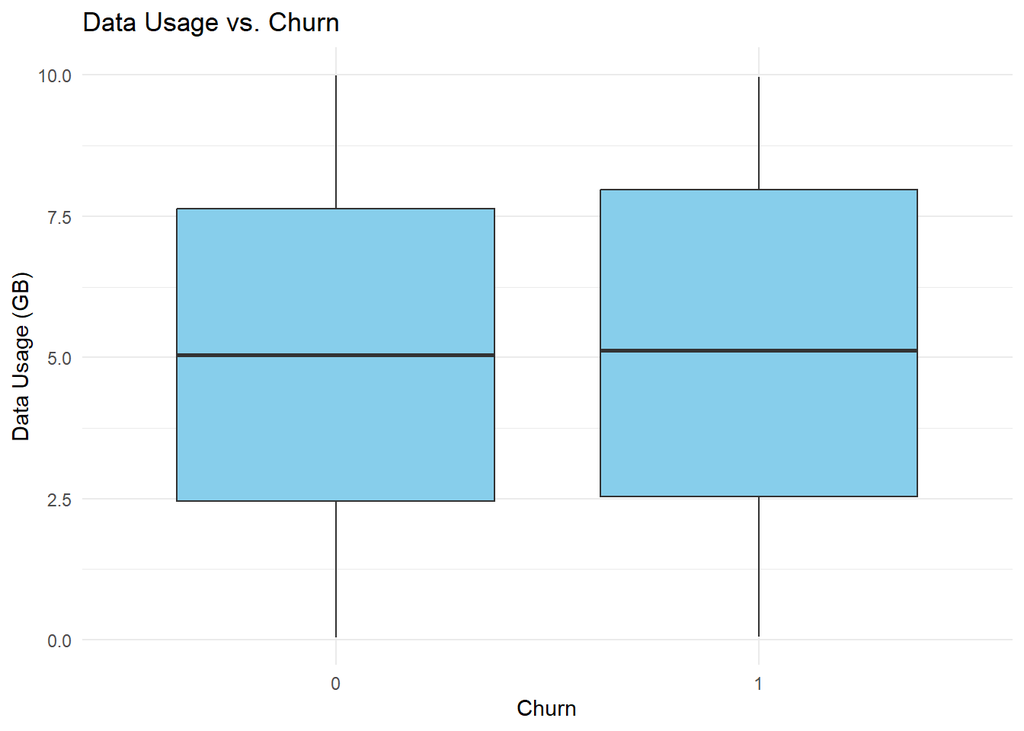

```r
ggplot(data, aes(x = as.factor(Churn), y = DataUsage)) +
  geom_boxplot(fill = "skyblue") +
  labs(title = "Data Usage vs. Churn", x = "Churn", y = "Data Usage (GB)") +
  theme_minimal()
```

# Interpretation

The box plot displays the data usage of churned and non-churned customers where churn shows the outcome of 1 and 0 respectively. Key observations include:

Median Data Usage: It is also the duration the two groups spend within the network; the median being almost similar with both groups averaging at approximately 5 GB data usage.

Interquartile Range (IQR): The IQR is pretty much the same indicating that the variation in data usage among the churned and non-churned customers is similar.

Outliers: In both the groups there aren’t actually any large exceptions to the overall pattern which is data usage.

Conclusion: Analyzing the boxplots, one can see that, probably, data usage can not be considered as the primary factor affecting customer churn, since both groups have rather similar median and shapes.

# Apply log transformation to Monthly Charges

```r
data$log_MonthlyCharges <- log(data$MonthlyCharges)
```

# Visualization using ggplot

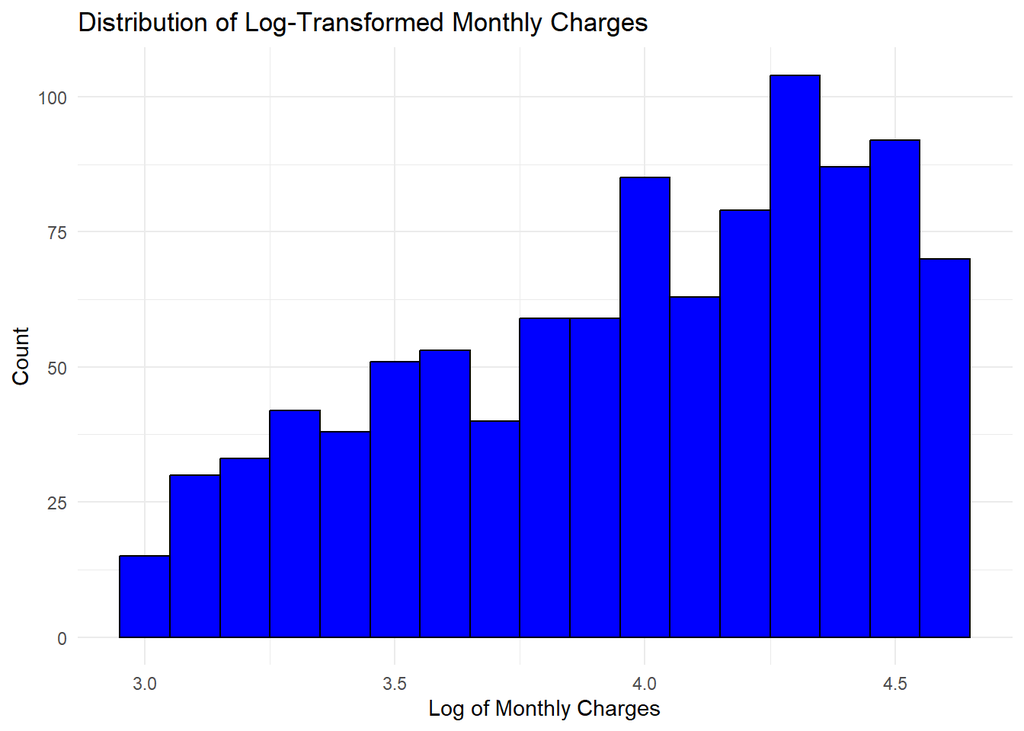

```r
ggplot(data, aes(x = log_MonthlyCharges)) +
  geom_histogram(binwidth = 0.1, fill ="blue", color = "black") +
  labs(title = "Distribution of Log-Transformed Monthly Charges", x = "Log of Monthly Charges", y = "Count") +
  theme_minimal()
```

#Interpretation of the Histogram: